# Final Project Optimization

## CPE 608: Applied Modeling and Optimization

## Fall 2022 Project: Optimization of Advertisement Budget

## Project Memebers

Priyank Thakur (CWID: 20009546)

Beula Jose (CWID: 10473421)

Simrat Kaur Anand (CWID: 20008654)

#### Import required modules

```python
%matplotlib inline
import matplotlib.pyplot as plt
import pandas as pd
import numpy as np
import seaborn as sb
from sklearn.linear_model import LinearRegression
from sklearn.linear_model import SGDRegressor
from sklearn.linear_model import Lasso
from sklearn.linear_model import ElasticNet
from sklearn.linear_model import Ridge
from sklearn.metrics import mean_squared_error
from sklearn.model_selection import train_test_split
from sklearn.preprocessing import StandardScaler
from pulp import *
```

## Import advertising dataset for project and display its Information

```python
df = pd.read_csv("advertising.csv")
```

```python
df
```

|  | TV | Radio | Newspaper | Sales |
| --- | --- | --- | --- | --- |
| 0 | 230.1 | 37.8 | 69.2 | 22.1 |
| 1 | 44.5 | 39.3 | 45.1 | 10.4 |
| 2 | 17.2 | 45.9 | 69.3 | 12.0 |
| 3 | 151.5 | 41.3 | 58.5 | 16.5 |
| 4 | 180.8 | 10.8 | 58.4 | 17.9 |
| ... | ... | ... | ... | ... |
| 195 | 38.2 | 3.7 | 13.8 | 7.6 |
| 196 | 94.2 | 4.9 | 8.1 | 14.0 |
| 197 | 177.0 | 9.3 | 6.4 | 14.8 |
| 198 | 283.6 | 42.0 | 66.2 | 25.5 |
| 199 | 232.1 | 8.6 | 8.7 | 18.4 |

200 rows × 4 columns

```python
df.info()
```

```
<class 'pandas.core.frame.DataFrame'>
RangeIndex: 200 entries, 0 to 199
Data columns (total 4 columns):
 #   Column     Non-Null Count  Dtype
---  ------     --------------  -----
 0   TV         200 non-null    float64
 1   Radio      200 non-null    float64
 2   Newspaper  200 non-null    float64
 3   Sales      200 non-null    float64
dtypes: float64(4)
memory usage: 6.4 KB
```

```python
df.describe()
```

|  | TV | Radio | Newspaper | Sales |
| --- | --- | --- | --- | --- |
| count | 200.000000 | 200.000000 | 200.000000 | 200.000000 |
| mean | 147.042500 | 23.264000 | 30.554000 | 15.130500 |
| std | 85.854236 | 14.846809 | 21.778621 | 5.283892 |
| min | 0.700000 | 0.000000 | 0.300000 | 1.600000 |
| 25% | 74.375000 | 9.975000 | 12.750000 | 11.000000 |
| 50% | 149.750000 | 22.900000 | 25.750000 | 16.000000 |
| 75% | 218.825000 | 36.525000 | 45.100000 | 19.050000 |
| max | 296.400000 | 49.600000 | 114.000000 | 27.000000 |

```python
df.mean()
```

```
TV           147.0425
Radio         23.2640
Newspaper     30.5540
Sales         15.1305
dtype: float64
```

- For imported dataset, it comprises 200 data points for each of the data variables, i.e., TV, Radio, Newspaper, and Sales. Columns "TV", "Radio", and "Newspaper" have recorded data for the budget in thousands of dollars. Column "Sales" has recorded data for the sales in thousands of units.
- The dataset gives one the opportunity to design an optimization problem of maximizing sales around a set of assumed constraints

## Visualizations for Dataset

**Pair plots**

*Here we compare the sales of each data variable*

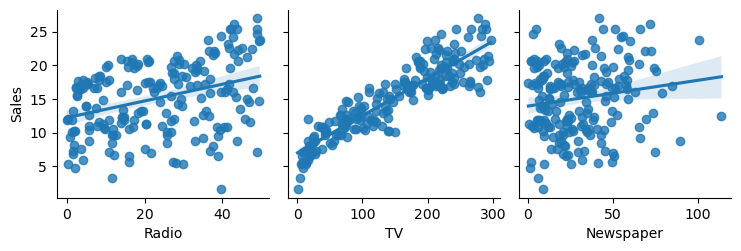

```python
sb.pairplot(df, x_vars=["Radio","TV","Newspaper"],y_vars= "Sales",kind="reg")
```

*Comparing data variables*

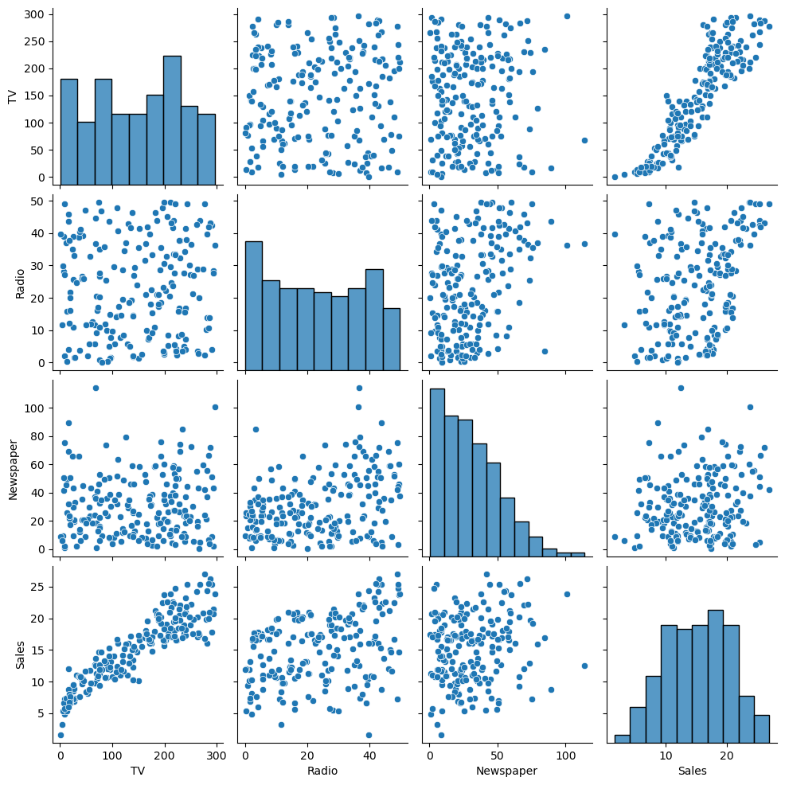

```python
sb.pairplot(df);
```

**Correlation heatmap**

*Correlation between different variables*

```
[Text(0.5, 1.0, 'Correlation Heatmap')]
```

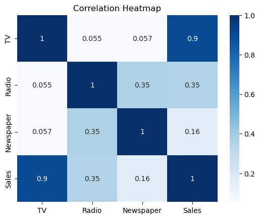

```python
corr = df.corr()
sb.heatmap(corr, cmap ='Blues', annot =True).set(title="Correlation Heatmap")
```

**Residual plots**

Here we compare the sales of data variables with each other

*TV Vs Sales*

```
[Text(0.5, 1.0, 'TV vs Sales')]
```

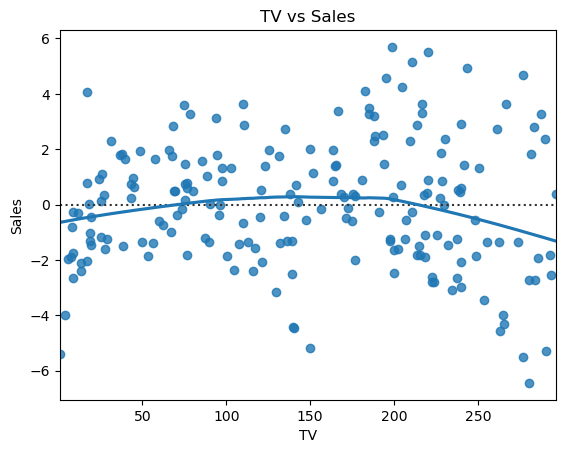

```python
sb.residplot(x = df['TV'], y = df['Sales'], lowess = True).set(title="TV vs Sales")
```

*Radio Vs Sales*

```
[Text(0.5, 1.0, 'Radio vs Sales')]
```

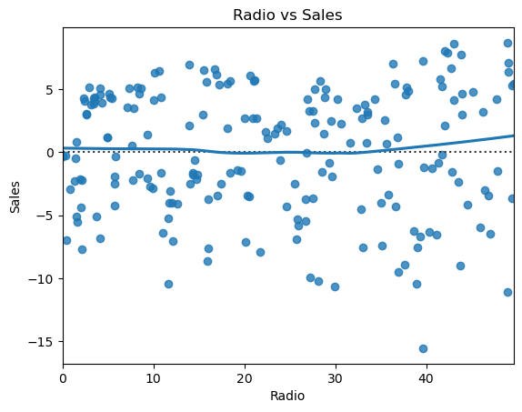

```python
sb.residplot(x = df['Radio'], y = df['Sales'], lowess = True).set(title="Radio vs Sales")
```

*Newspaper Vs Sales*

```
[Text(0.5, 1.0, 'Newspaper vs Sales')]
```

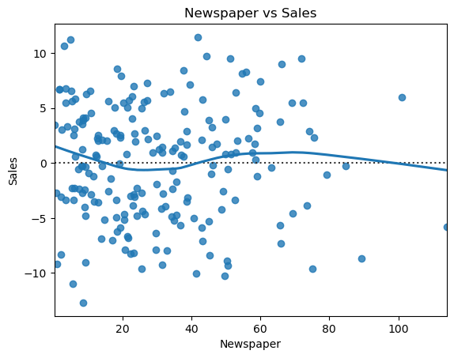

```python
sb.residplot(x = df['Newspaper'], y = df['Sales'], lowess = True).set(title="Newspaper vs Sales")
```

**Adding an additional column for average budget across different media**

```python
df['Average Budget'] = df[['TV', 'Radio', 'Newspaper']].mean(numeric_only=True, axis=1)
df
```

|  | TV | Radio | Newspaper | Sales | Average Budget |
| --- | --- | --- | --- | --- | --- |
| 0 | 230.1 | 37.8 | 69.2 | 22.1 | 112.366667 |
| 1 | 44.5 | 39.3 | 45.1 | 10.4 | 42.966667 |
| 2 | 17.2 | 45.9 | 69.3 | 12.0 | 44.133333 |
| 3 | 151.5 | 41.3 | 58.5 | 16.5 | 83.766667 |
| 4 | 180.8 | 10.8 | 58.4 | 17.9 | 83.333333 |
| ... | ... | ... | ... | ... | ... |
| 195 | 38.2 | 3.7 | 13.8 | 7.6 | 18.566667 |
| 196 | 94.2 | 4.9 | 8.1 | 14.0 | 35.733333 |
| 197 | 177.0 | 9.3 | 6.4 | 14.8 | 64.233333 |
| 198 | 283.6 | 42.0 | 66.2 | 25.5 | 130.600000 |
| 199 | 232.1 | 8.6 | 8.7 | 18.4 | 83.133333 |

200 rows × 5 columns

**Scatter plot**

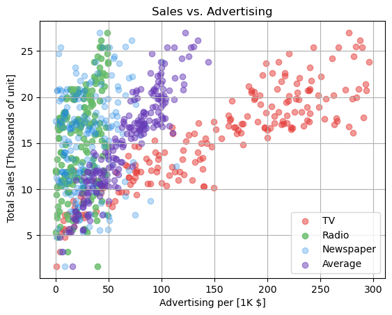

```python
plt.scatter(df['TV'],df['Sales'],c="#E53935",alpha=0.5, label='TV')
plt.scatter(df['Radio'],df['Sales'],c="#66BB6A",alpha=0.8, label='Radio')
plt.scatter(df['Newspaper'],df['Sales'],c="#1E88E5",alpha=0.3, label= 'Newspaper')
plt.scatter(df['Average Budget'],df['Sales'],c="#673AB7",alpha=0.5, label= 'Average')
plt.legend(loc="lower right")
plt.title("Sales vs. Advertising")
plt.xlabel("Advertising per [1K $]")
plt.ylabel(" Total Sales [Thousands of unit]")
plt.grid()
plt.show()
```

#### Optimization Problem

**Problem Statement:**

1. A budget constraint restricting the total amount of money to be allocated among three different channels (TV, Radio, Newspaper) takes the form x1 + x2 + x3 ≤ B, where B is the budget.
2. The total spend for each of these channels (TV, Radio, Newspaper) should be less than or equal to some constraints t, r, and n while total budget is capped at B.
3. Find out the objective function where we plan to maximize or minimize sales.

**Approach:**

```python
y = df['Sales']
x = df[['Average Budget']]
x_train, x_test, y_train, y_test = train_test_split(x, y, test_size=0.20, random_state=57)
```

**Using Linear Regression**

```python
regression = LinearRegression()
regression.fit(x_train,y_train)
rgs_y_pred = regression.predict(x_test)
rgs_score = regression.score(x_test, y_test)
rgs_MSE = np.sqrt(mean_squared_error(y_test,rgs_y_pred))
rgs_coef = regression.coef_
rgs_intercept = regression.intercept_
print("Metrics for Linear Regression are as follows:")
print("-"*40)
print("Score:\t", rgs_score)
print("Error:\t", rgs_MSE)
print("Coef:\t",rgs_coef[0])
print("Intercept:\t",rgs_intercept)
```

```
Metrics for Linear Regression are as follows:
----------------------------------------
Score:	 0.8723010124704045
Error:	 2.026016654732277
Coef:	 0.15518937421349988
Intercept:	 4.671512412906933
```

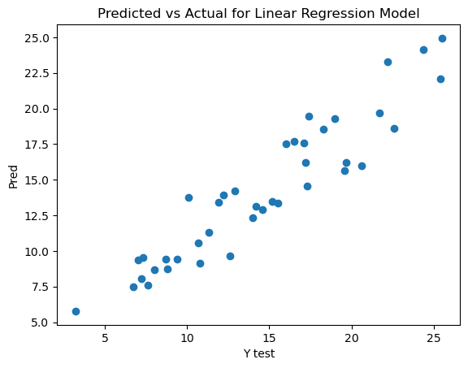

```python
plt.scatter(y_test,rgs_y_pred)
plt.ylabel('Pred')
plt.xlabel('Y test')
plt.title("Predicted vs Actual for Linear Regression Model")
plt.show()
```

**Using Lasso Model**

```python
lasso = Lasso(alpha= 0.01)
lasso.fit(x_train,y_train)
lss_y_pred = lasso.predict(x_test)
lss_score = lasso.score(x_test, y_test)
lss_MSE = np.sqrt(mean_squared_error(y_test,lss_y_pred))
lss_coef = lasso.coef_
lss_intercept = lasso.intercept_
print("Metrics for Lasso Model are as follows:")
print("-"*40)
print("Score:\t", lss_score)
print("Error:\t", lss_MSE)
print("Coef:\t",lss_coef[0])
print("Intercept:\t",lss_intercept)
```

```
Metrics for Lasso Model are as follows:
----------------------------------------
Score:	 0.8722934450614519
Error:	 2.0260766844542673
Coef:	 0.15517870012065144
Intercept:	 4.672242463039764
```

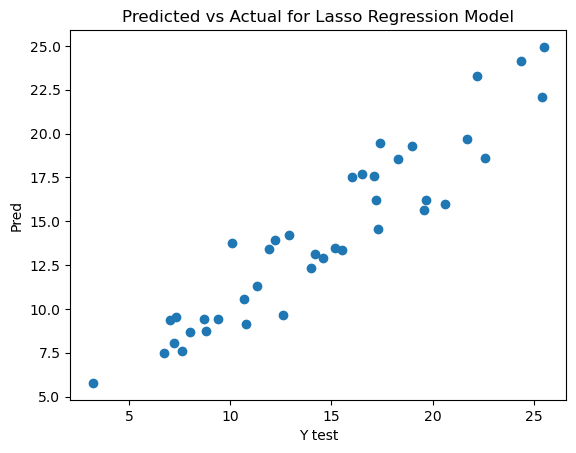

```python
plt.scatter(y_test,lss_y_pred)
plt.ylabel('Pred')
plt.xlabel('Y test')
plt.title("Predicted vs Actual for Lasso Regression Model")
plt.show()
```

**Using Ridge Model**

```python
rm = Ridge(alpha=0.01)
rm.fit(x_train, y_train)
rm_y_pred= rm.predict(x_test)
rm_score = rm.score(x_test, y_test)
rm_MSE = np.sqrt(mean_squared_error(y_test,rm_y_pred))
rm_coef = rm.coef_
rm_intercept = rm.intercept_
print("Metrics for Ridge Model are as follows:")
print("-"*40)
print("Score:\t", rm_score)
print("Error:\t", rm_MSE)
print("Coef:\t",rm_coef[0])
print("Intercept:\t",rm_intercept)
```

```
Metrics for Ridge Model are as follows:
----------------------------------------
Score:	 0.8723010051341012
Error:	 2.0260167129295756
Coef:	 0.1551893638603394
Intercept:	 4.671513121007029
```

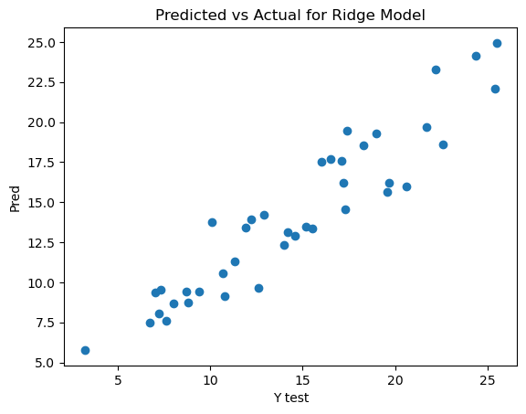

```python
plt.scatter(y_test,rm_y_pred)
plt.ylabel('Pred')
plt.xlabel('Y test')
plt.title("Predicted vs Actual for Ridge Model")
plt.show()
```

**Using Elastic Net**

```python
enet = ElasticNet(alpha = 0.01)
enet.fit(x_train, y_train)
enet_y_pred = enet.predict(x_test)
enet_score = enet.score(x_test, y_test)
enet_MSE = np.sqrt(mean_squared_error(y_test,enet_y_pred))
enet_coef = enet.coef_
enet_intercept = enet.intercept_
print("Metrics for Elastic Net are as follows:")
print("-"*40)
print("Score:\t", enet_score)
print("Error:\t", enet_MSE)
print("Coef:\t",enet_coef[0])
print("Intercept:\t",enet_intercept)
```

```
Metrics for Elastic Net are as follows:
----------------------------------------
Score:	 0.8722966425000338
Error:	 2.026051320461346
Coef:	 0.1551832089470853
Intercept:	 4.671934083734499
```

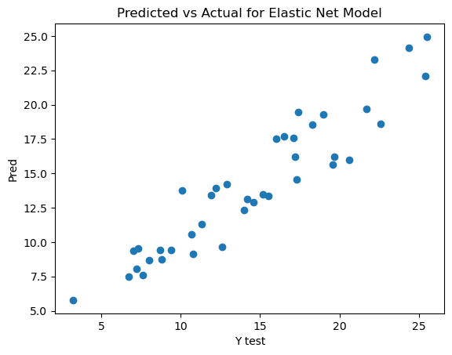

```python
plt.scatter(y_test,enet_y_pred)
plt.ylabel('Pred')
plt.xlabel('Y test')
plt.title("Predicted vs Actual for Elastic Net Model")
plt.show()
```

```python
avg_coef = (rgs_coef+lss_coef+rm_coef+enet_coef)/4
avg_intercept = (rgs_intercept+lss_intercept+rm_intercept+enet_intercept)/4
print("Average Metrics for all Models")
print("-"*40)
print("Average Coef: "+str(avg_coef[0]))
print("Average Intercept: "+str(avg_intercept))
```

```
Average Metrics for all Models
----------------------------------------
Average Coef: 0.155185161785394
Average Intercept: 4.671800520172056
```

**Constraints:**

Let the constraint on the total budget B be 1000, i.e., (T+R+N) <= 1000.

Let the constraint on each of the channels be as follows: T <= 200 R <= 500 N <= 500

*Objective Function to Maximize Sales using PuLP*

```python
OpProb = LpProblem("AdvsSalesOpt", LpMaximize)
T = LpVariable("TV", 0, 200)
R = LpVariable("Radio", 0, 500)
N = LpVariable("Newspaper", 0, 500)
OpProb += T + R + N <= 1000
OpProb +=  0.05367932*T + 0.11150177*R - 0.0034977*N + 4.773466912078015
status = OpProb.solve()
LpStatus[status]
```

```
'Optimal'
```

```python
print(OpProb)
for v in OpProb.variables():
    print(v.name, "=", v.varValue)
```

```
AdvsSalesOpt:
MAXIMIZE
-0.0034977*Newspaper + 0.11150177*Radio + 0.05367932*TV + 4.773466912078015
SUBJECT TO
_C1: Newspaper + Radio + TV <= 1000

VARIABLES
Newspaper <= 500 Continuous
Radio <= 500 Continuous
TV <= 200 Continuous

Newspaper = 0.0
Radio = 500.0
TV = 200.0
```

```python
print("Objective Value = %f" % (OpProb.objective.value()))
# Optimized Value for Sales, Confirmation through calculation
OptVal = 0.05368006*200 + 0.11152624*500 - 0.00351166*0 + 4.773205203269837
print("Optimized Budget Sales: ",OptVal)
```

```
Objective Value = 71.260216
Optimized Budget Sales:  71.27233720326984
```